# correlación_lineal

2024-03-16

```r
library(readxl)
data <- as.data.frame(read_excel("C:/Ejercicios/correlacion_lineal/data.xls"))
View(data)
print(data)
```

```
##    id  peso altura
## 1   1 23.47  34.72
## 2   2  5.81  87.59
## 3   3 67.92  16.28
## 4   4 12.36  52.94
## 5   5 38.09  11.67
## 6   6 54.73  65.83
## 7   7 89.24  28.15
## 8   8 16.57  43.26
## 9   9 73.10  78.94
## 10 10 42.85  25.09
## 11 11  6.28  59.37
## 12 12 91.63  37.62
## 13 13 29.04  20.48
## 14 14 50.17  91.75
```

[output cut: 16 more lines]

#Actividad 1:

La correlación lineal es una medida estadística que evalúa la relación lineal entre dos variables cuantitativas. Es una medida de la fuerza y la dirección de la relación entre estas dos variables. Cuando dos variables tienen una correlación lineal positiva, significa que a medida que una variable aumenta, la otra también tiende a aumentar. Por otro lado, una correlación lineal negativa indica que a medida que una variable aumenta, la otra tiende a disminuir.

La correlación lineal se representa mediante el coeficiente de correlación, comúnmente denotado como “r”. Este coeficiente oscila entre -1 y 1. Un valor de 1 indica una correlación lineal perfecta positiva, -1 indica una correlación lineal perfecta negativa, y 0 indica que no hay correlación lineal entre las dos variables.

Es importante tener en cuenta que la correlación lineal no implica causalidad. Es decir, el hecho de que dos variables estén correlacionadas linealmente no significa necesariamente que una cause la otra; puede haber otros factores involucrados que influyan en la relación entre las variables

#Actividad 2:

La correlación lineal se considera una prueba de correlación paramétrica porque asume que los datos siguen una distribución específica, típicamente una distribución normal, y que tienen una relación lineal entre sí. Las pruebas paramétricas, en general, requieren que los datos cumplan ciertas suposiciones sobre la distribución de la población subyacente y la naturaleza de los datos.

Las pruebas paramétricas son aquellas que se basan en parámetros específicos de la población subyacente, como la media y la varianza. Estas pruebas son más poderosas cuando se cumplen las suposiciones subyacentes y pueden proporcionar estimaciones más precisas de los parámetros poblacionales.

Por otro lado, las pruebas no paramétricas son aquellas que no hacen suposiciones sobre la distribución de la población subyacente. Estas pruebas son útiles cuando los datos no cumplen con los supuestos de normalidad u otras suposiciones paramétricas. Las pruebas no paramétricas son menos sensibles a las desviaciones de la normalidad y a otros supuestos, pero pueden ser menos potentes cuando se cumplen las suposiciones paramétricas.

En resumen, las pruebas paramétricas como la correlación lineal requieren ciertas suposiciones sobre la distribución de los datos y la naturaleza de la relación entre las variables, mientras que las pruebas no paramétricas son más flexibles en términos de suposiciones pero pueden ser menos potentes en ciertas situaciones.

#Actividad 3. Calcula la correlación entre las variables almacenadas en la tabla ‘data’.

```r
correlacion_datos <- cor(data)
print(correlacion_datos)
```

```
##                 id       peso      altura
## id     1.000000000 0.08321171 0.003792534
## peso   0.083211709 1.00000000 0.147768260
## altura 0.003792534 0.14776826 1.000000000
```

#Actividad 4. Calcula los coeficientes de correlación de las variables junto con el nivel de significancia (p-value) en 1 solo gráfico. Interpreta los resultados.

```r
panel.cor <- function(x, y, digits = 2, prefix = "", cex.cor, ...) {
  usr <- par("usr")
  on.exit(par(usr))
  par(usr = c(0, 1, 0 ,1))
  Cor <- abs(cor(x, y))
  txt <- paste0(prefix, format(c(Cor, 0.123456789), digits = digits)[1])
  if(missing(cex.cor)) {
    cex.cor <- 0.4 / strwidth(txt)
  }
  text(0.5, 0.5, txt,
       cex = 1 + cex.cor*Cor)
}
```

#Aquí dibujamos la matriz de correlación

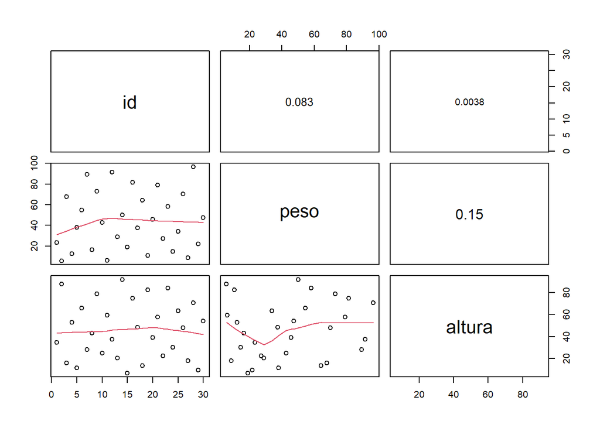

```r
pairs(data,
      upper.panel = panel.cor, # Este es el panel de correlación
      lower.panel = panel.smooth)
```

Actividad 5. ### Ejercicio 5. Emplea una función para obtener en una matriz de correlación lineal, IC 95% y p-value de todas las variables en el data frame ‘data’.

```r
library(correlation)
matriz <- correlation(data)
matriz
```

```
## # Correlation Matrix (pearson-method)
##
## Parameter1 | Parameter2 |        r |        95% CI | t(28) |      p
## -------------------------------------------------------------------
## id         |       peso |     0.08 | [-0.29, 0.43] |  0.44 | > .999
## id         |     altura | 3.79e-03 | [-0.36, 0.36] |  0.02 | > .999
## peso       |     altura |     0.15 | [-0.22, 0.48] |  0.79 | > .999
##
## p-value adjustment method: Holm (1979)
## Observations: 30
```

```r
library(ggpubr)
```

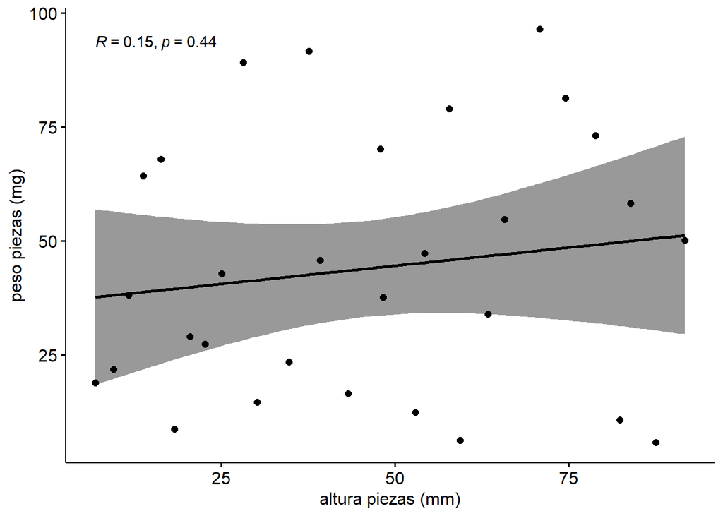

```r
library(ggplot2)
ggscatter(data, x = "altura", y = "peso",
          add = "reg.line", conf.int = TRUE,
          cor.coef = TRUE, cor.method = "pearson",
          xlab = "altura piezas (mm)", ylab = "peso piezas (mg)")
```

### Ejercicio 7. Emplea la librería ‘corrplot()’ para visualizar la correlación entre variables.

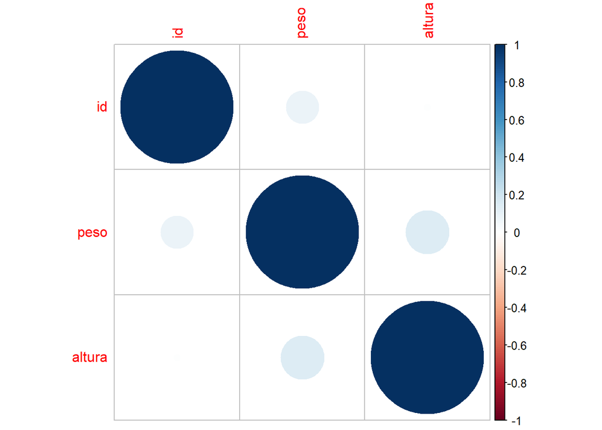

```r
library(corrplot)
corrplot(cor(data))
```

### Ejercicio 8. A partir de la siguiente secuncia de valores numéricos:

#a) Creamos 2 vectores: ‘distancia’ y ‘n_piezas’ para almacenarlos en un data frame:

```r
distancia <- c( 1.1,100.2,90.3,5.4,57.5,6.6,34.7,65.8,57.9,86.1)
n_piezas <- c(110,2,6,98,40,94,31,5,8,10)
datos_2 <- data.frame(distancia, n_piezas)
print(datos_2)
```

```
##    distancia n_piezas
## 1        1.1      110
## 2      100.2        2
## 3       90.3        6
## 4        5.4       98
## 5       57.5       40
## 6        6.6       94
## 7       34.7       31
## 8       65.8        5
## 9       57.9        8
## 10      86.1       10
```

#b) Calcula el coeficiente de correlación:

```r
correlacion_datos_2 <- cor(datos_2)
print(correlacion_datos_2)
```

```
##            distancia   n_piezas
## distancia  1.0000000 -0.9249824
## n_piezas  -0.9249824  1.0000000
```

#c) Calcula el nivel de significancia:

```r
significancia_datos_2 <- cor.test(datos_2$distancia, datos_2$n_piezas)$p.value
print(significancia_datos_2)
```

```
## [1] 0.0001264706
```

#d) Calcula el Intervalo de confianza al 95% en relación con el coeficiente de correlación:

```r
intervaloconfianza_datos_2 <- cor.test(datos_2$distancia, datos_2$n_piezas)$conf.int
print(intervaloconfianza_datos_2)
```

```
## [1] -0.9824414 -0.7072588
## attr(,"conf.level")
## [1] 0.95
```

#e) ¿Qué intensidad y dirección presentan ambas variables?

La intensidad es alta debido al acercarse a la cifra 1.

#f) ¿Es significativa esta relación?

Sí.

#g) Resulta apropiado afirmar la correlación (o no) entre variables con un tamaño muestral tan reducido (n=10).

No, ya que se necesita mas variabilidad de datos.

#9 Explícame con un ejemplo en R la diferencia entre una relación lineal y monótona entre 2 variables Primero, generaremos datos para ambos tipos de relaciones y luego visualizaremos los resultados utilizando gráficos de dispersión y ajustes de línea.

# Cargamos la librería necesaria

library(ggplot2)

# Creamos datos para una relación lineal

# Creamos datos para una relación monótona no lineal

# Crear un dataframe para cada tipo de relación

# Gráfico de dispersión y ajuste lineal para relación lineal

# Gráfico de dispersión y ajuste lineal para relación monótona

# 10) ¿Qué tipo de prueba de correlación se aplica a las variables que experimentan una relación monótona? Expón un ejemplo en R.

Cuando las variables muestran una relación monótona, es más apropiado utilizar pruebas de correlación no paramétricas. Una de las pruebas más comunes para evaluar la correlación en este contexto es la prueba de correlación de Spearman. Esta prueba calcula el coeficiente de correlación de Spearman, que mide la relación monotónica entre dos variables.

# Ejemplo de prueba de correlación de Spearman en R

# Cargamos la librería necesaria

library(stats)

# Creamos datos para una relación monótona

# Creamos un dataframe con los datos

# Realizamos la prueba de correlación de Spearman

# Mostramos los resultados

print(cor_spearman)

En este ejemplo, generamos datos para una relación monótona no lineal y luego aplicamos la prueba de correlación de Spearman utilizando la función cor.test() con el parámetro method = “spearman”. Esta función calcula el coeficiente de correlación de Spearman y realiza una prueba de hipótesis para determinar si la correlación es significativa.

Es importante recordar que la prueba de correlación de Spearman es adecuada para evaluar la correlación entre variables cuando la relación no es necesariamente lineal, pero sigue una tendencia monotónica.